# Lecture 1 Code

Alex Hoagland

2022-09-09

```r
# I like to include several additional notes in the header of my files here:
#
# Last modified: 8/11/2022
#
### PURPOSE:
  # Lecture 1 code and output file
#
### NOTES:
  # - uses the Tidyverse package and Dplyr
```

## Starting with R: Some things to be aware of

- Where is RStudio “pointed at” – what’s the current directory?
  - We’ll talk more about project organization as we proceed through the course
- Using *projects* in R – keeping files altogether
- RStudio is meant to be an “all-in-one” tool; you can use this to code (duh), but also to make and format output including figures, tables, documents (like this one), slides, and even apps!
- This makes it a convenient one-stop-shop for everything you do in a research project!

## R Markdown: Introduction

R Markdown documents are the files used to create HTML, PDF, and MS Word documents. For more details on using R Markdown see http://rmarkdown.rstudio.com.

You can embed code (and its output) into these files. When you click the **Knit** button a document will be generated that includes both content as well as the output of any embedded R code chunks within the document.

You can embed an R code chunk like this:

```r
# Any commands you want to have happen go here
# summary(mydata) # note: what does R look like? What's a comment?
```

## Packages in R

R is a collaborative open-source language, which means people write and share packages that do all sorts of helpful things. We’ll make use of some of the most common packages for econometric reserach throughout this course.

```r
# The packages we will need for this file
# install.packages('tidyverse') # if you need to install the package, uncomment this line.
library(tidyverse) # load the installed package for each new session of R
```

## User-Defined Functions

We can also define our own functions. This will become more important as the things we want to do in a single code file become more and more complex. Additionally, many econometricians like to code up their own estimators to really feel confident that they understand what is happening “under the hood” (we won’t do much of this here.)

```r
gap <- function() # This line names the function "gap" and tells R that it's a function.
    # Any arguments you need go in the parentheses
{ # Always have brackets around function definitions
  sdo <-  tibble( # This creates a data frame with 3 variables and 10 observations
    y1 = c(7,5,5,7,4,10,1,5,3,9),
    y0 = c(1,6,1,8,2,1,10,6,7,8),
    random = rnorm(10)
  ) %>% # what si a pipe operator?
    arrange(random) %>% # Sort the data frame by the random variable (i.e., a random sort)
    mutate( # Mutate = creating new variables
      d = c(rep(1,5), rep(0,5)), # Assigns a treatment variable
      y = d * y1 + (1 - d) * y0 # The switching equation to tell us which outcome we observe
    ) %>%
    pull(y) # This line keeps only the observed outcome

  sdo <- mean(sdo[1:5]-sdo[6:10]) # This is the outcome of interest: the estimated ATE based on observed data

  return(sdo) # This line tells the function what to return (the outcome we want)
} # Don't forget to close the brackets

# Let's test the function
gap()
```

```
## [1] 1
```

```r
test <- gap() # What happens when we run this multiple times? Why?
```

Now that we’ve defined a function, we can use it! Let’s run the gap function 10,000 times in our first **monte carlo simulation**

```r
sim <- replicate(10000, gap())
mean(sim)
```

```
## [1] 0.59096
```

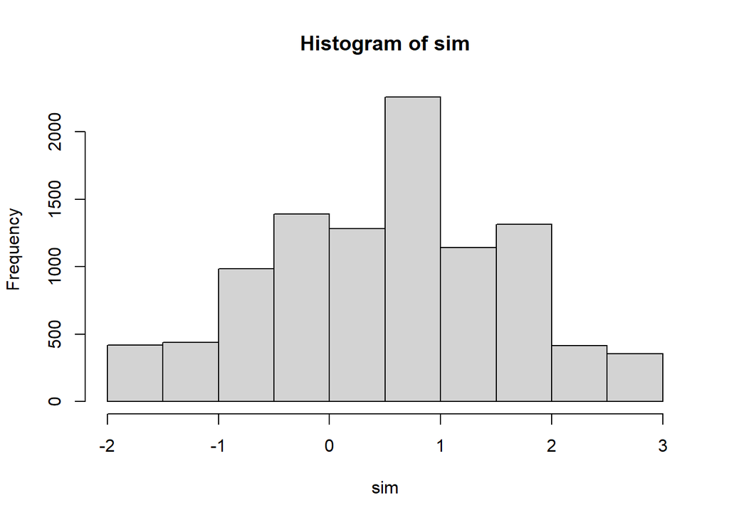

```r
hist(sim)
```

We see that the average estimated effect is almost 0.6! We can create a simple visualization of the simulation results using baseR graphics.

## Quick introduction to ggplot

Another, vastly superior method to graphics is dplyr’s “ggplot”, which follows the dplyr language to make more publication-ready figures. It’s extremely versatile! I recommend this book if you are looking to master ggplot: https://tinyurl.com/4k4wj8px

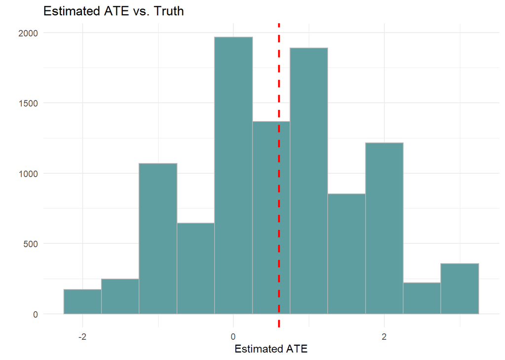

```r
sim <- tibble(sim) # We need a data frame for ggplot to work
ggplot(data=sim, aes(sim))+
  geom_histogram(binwidth=.5,color='gray70',fill='cadetblue') +
  theme_minimal() +
  labs(x="Estimated ATE", y="",title="Estimated ATE vs. Truth") +
  geom_vline(xintercept=0.6, color="red", linetype="dashed",size=1)
```

```r
  # Notes:
    # First, need to tell ggplot what tibble object to look at (sim)
    # Then, the aes() command tells ggplot which variables to use. This depends on the particular
    #   geom() you want.
    #   Since we are making a one-variable histogram, we need only reference the variable we have
    # geom_histogram() makes the histogram.
    #   See <http://www.stat.columbia.edu/~tzheng/files/Rcolor.pdf> for colors in R
    # theme_minimal() is a nice theme to use for the background.
    #   More themes here: <https://ggplot2.tidyverse.org/reference/ggtheme.html>
    # labs() defines the labels of interest
    # geom_vline() makes a vertical line at the true ATE (in this case, 0.6).
```

## What do we do at the end of an RMarkdown file?

First, make sure to cite all the packages you used – it’s just as important to give credit to coding work as it is to other types of previous scholarly work.

Let’s knit this file and save it!